# 6345_COMP3

2023-12-16

```r
library(dplyr)
library(janitor)
library(corrr)
library(car)
library(effectsize)
source("610710_functions.R")
library(psych)
```

```r
library(ggplot2)
```

# Part 1: Conceptual Questions

## 1.

### a.

perf = b0 + b1*adhd + b2*condition + b3*speed + b4*adhd*condition

### b.

perf = b0 + b1*adhd

### c.

perf = b0 + b1*adhd + b2*condition + b3*adhd*condition

## 2.

One complication of the testing of interactions with measured predictors is unreliability in the predictors. Unreliability significantly reduces power since reliability is a product term. Another complication is the restriction in range of the predictors; if a predictor does not vary much, it makes it harder to find a relationship between variables.

## 3.

The additive assumption is when you regress your outcome variable on two predictors and the slope of the outcome variable on one predictor does not change as a function on the other predictor. Because of this, you can add the effects of both predictors when you take the derivative. This assumption’s reasonableness depends on the specific context being studied. It emphasizes the importance of tailoring statistical approaches to the unique features of the research domain to ensure that the analysis is meaningful and valid within that context.

# Part 2: Data Analysis

# Study 1

## 1.

```r
d <- read.csv("med_school.csv") %>% janitor::clean_names()
describe(d)
```

```
##            vars   n  mean    sd median trimmed   mad min   max range  skew
## id            1 150 75.50 43.45   75.5   75.50 55.60   1 150.0 149.0  0.00
## time          2 150 10.74  5.84   12.0   10.90  7.41   1  20.0  19.0 -0.19
## workshop      3 150  0.52  0.50    1.0    0.53  0.00   0   1.0   1.0 -0.08
## confidence    4 150  3.73  1.90    3.9    3.70  1.93   0   9.7   9.7  0.16
##            kurtosis   se
## id            -1.22 3.55
## time          -1.28 0.48
## workshop      -2.01 0.04
## confidence    -0.30 0.16
```

```r
correlate(d)
```

```
## Correlation computed with
## • Method: 'pearson'
## • Missing treated using: 'pairwise.complete.obs'
```

```
## # A tibble: 4 × 5
##   term             id    time workshop confidence
##   <chr>         <dbl>   <dbl>    <dbl>      <dbl>
## 1 id         NA        0.0500 -0.00801    -0.116
## 2 time        0.0500  NA       0.0580      0.311
## 3 workshop   -0.00801  0.0580 NA           0.0493
## 4 confidence -0.116    0.311   0.0493     NA
```

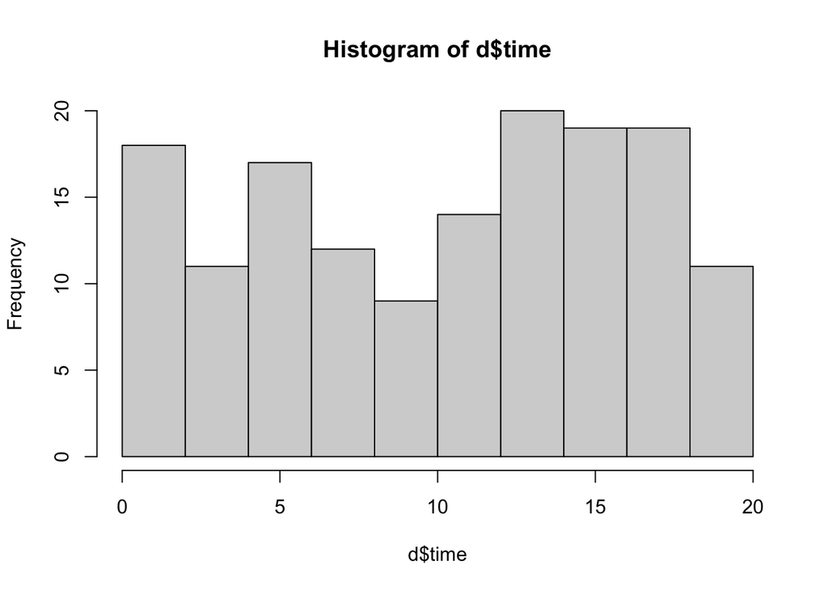

```r
hist(d$time)
```

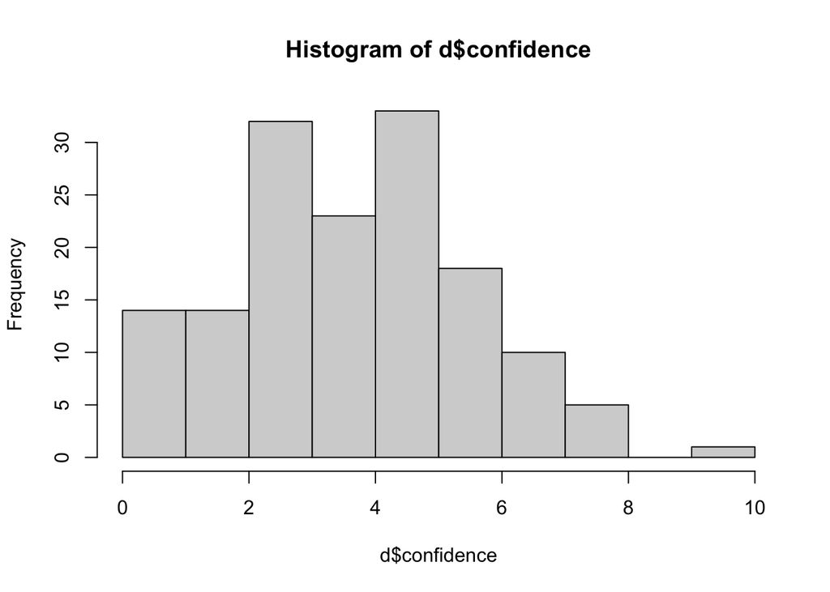

```r
hist(d$confidence)
```

None of the variables seem to have any impossible values. The confidence variable has one value that is higher than the others, but still within the expected range. The predicors seem to mostly have very weak correlations with each other. The only correlation that is slightly less weak is confidence and time.

## 2.

```r
m1 <- lm(confidence ~ time + workshop, data = d)
summary(m1)
```

```
##
## Call:
## lm(formula = confidence ~ time + workshop, data = d)
##
## Residuals:
##     Min      1Q  Median      3Q     Max
## -4.5174 -1.2735  0.1023  1.3486  5.1826
##
## Coefficients:
##             Estimate Std. Error t value Pr(>|t|)
## (Intercept)  2.58289    0.34157   7.562 3.97e-12 ***
## time         0.10084    0.02558   3.942 0.000125 ***
## workshop     0.11930    0.29803   0.400 0.689512
## ---
## Signif. codes:  0 '***' 0.001 '**' 0.01 '*' 0.05 '.' 0.1 ' ' 1
##
## Residual standard error: 1.821 on 147 degrees of freedom
## Multiple R-squared:  0.0978, Adjusted R-squared:  0.08552
## F-statistic: 7.967 on 2 and 147 DF,  p-value: 0.0005186
```

```r
car::Anova(m1, type = 3) %>% eta_squared()
```

```
## # Effect Size for ANOVA (Type III)
##
## Parameter | Eta2 (partial) |       95% CI
## -----------------------------------------
## time      |           0.10 | [0.03, 1.00]
## workshop  |       1.09e-03 | [0.00, 1.00]
##
## - One-sided CIs: upper bound fixed at [1.00].
```

b0 is 2.58; this is what our model predicts confidence scores to be for a participant who has a score of 0 on time and workshop. b1 is 0.10; this is the effect of time on confidence when controlling for workshop. b2 is 0.12; this is the effect of workshop on confidence when controlling for time. F(2,147)=7.967, p < .001, ηp2 time = .10, ηp2 workshop = .001.

## 3.

```r
m2 <- lm(confidence ~ time + I(time^2) + workshop, data = d)
summary(m2)
```

```
##
## Call:
## lm(formula = confidence ~ time + I(time^2) + workshop, data = d)
##
## Residuals:
##     Min      1Q  Median      3Q     Max
## -4.9383 -1.1000 -0.0097  1.2396  4.7617
##
## Coefficients:
##              Estimate Std. Error t value Pr(>|t|)
## (Intercept)  3.763789   0.489131   7.695 1.95e-12 ***
## time        -0.236742   0.105944  -2.235  0.02696 *
## I(time^2)    0.016606   0.005067   3.277  0.00131 **
## workshop     0.055465   0.289273   0.192  0.84821
## ---
## Signif. codes:  0 '***' 0.001 '**' 0.01 '*' 0.05 '.' 0.1 ' ' 1
##
## Residual standard error: 1.763 on 146 degrees of freedom
## Multiple R-squared:  0.1596, Adjusted R-squared:  0.1424
## F-statistic: 9.244 on 3 and 146 DF,  p-value: 1.228e-05
```

```r
car::Anova(m2, type=3, data =d) %>% eta_squared()
```

```
## # Effect Size for ANOVA (Type III)
##
## Parameter | Eta2 (partial) |       95% CI
## -----------------------------------------
## time      |           0.03 | [0.00, 1.00]
## I(time^2) |           0.07 | [0.02, 1.00]
## workshop  |       2.52e-04 | [0.00, 1.00]
##
## - One-sided CIs: upper bound fixed at [1.00].
```

b0 is 3.76; this is the effect of time on confidence for participants who have a score of 0 on time and workshop. b1 is -0.24; this is the linear effect of time on confidence when statistically controlling for the quadratic effect of time and the linear effect of workshop. b2 is 0.017; this is the quadratic effect of time on confidence when statistically controlling for the linear effects of time and workshop. Practically, this is the curvature of the line and half the amount the slope changes at every observation. b3 is 0.055; this is the linear effect of workshop on confidence when statistically controlling for both the linear and quadratic effects of time. F(3,146)=9.24, p<.001, ηp2 time = .03, ηp2 time^2 = .07, ηp2 workshop = .0003.

## 4.

```r
d$time_c <- d$time - mean(d$time)
m3 <- lm(confidence ~ time_c + I(time_c^2) + workshop, data = d)
summary(m3)
```

```
##
## Call:
## lm(formula = confidence ~ time_c + I(time_c^2) + workshop, data = d)
##
## Residuals:
##     Min      1Q  Median      3Q     Max
## -4.9383 -1.1000 -0.0097  1.2396  4.7617
##
## Coefficients:
##             Estimate Std. Error t value Pr(>|t|)
## (Intercept) 3.136666   0.263303  11.913  < 2e-16 ***
## time_c      0.119959   0.025453   4.713 5.64e-06 ***
## I(time_c^2) 0.016606   0.005067   3.277  0.00131 **
## workshop    0.055465   0.289273   0.192  0.84821
## ---
## Signif. codes:  0 '***' 0.001 '**' 0.01 '*' 0.05 '.' 0.1 ' ' 1
##
## Residual standard error: 1.763 on 146 degrees of freedom
## Multiple R-squared:  0.1596, Adjusted R-squared:  0.1424
## F-statistic: 9.244 on 3 and 146 DF,  p-value: 1.228e-05
```

.120 is the linear effect of time on confidence at the mean when controlling for the quadratic effect of time and the linear effect workshop.

## 5.

```r
describe(d$time_c)
```

```
##    vars   n mean   sd median trimmed  mad   min  max range  skew kurtosis   se
## X1    1 150    0 5.84   1.26    0.16 7.41 -9.74 9.26    19 -0.19    -1.28 0.48
```

## 6.

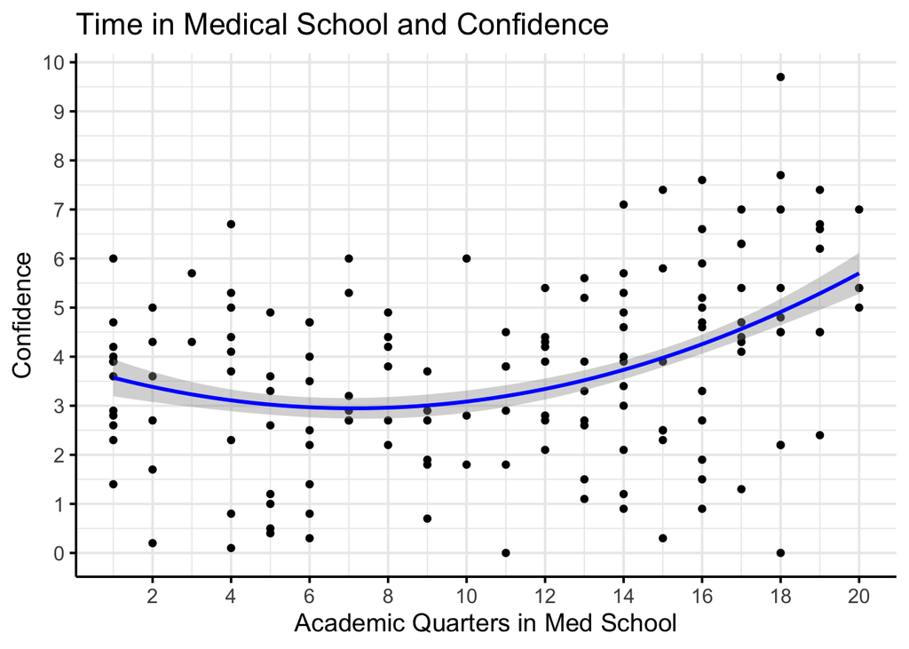

```r
d$workshop_c <- dplyr::recode(d$workshop, "0" = -.5, "1" = .5)
d_input <- data.frame(time = seq(min(d$time), max(d$time), length = 60),
                      workshop_c = 0)

m_graph <- lm(confidence ~ time + I(time^2) + workshop_c, data = d)

d_predictions <- ggplotPredict(m_graph, d_input)

scatterplot <- ggplot() +
  geom_point(data = d, aes(x = time, y = confidence), color = "black") +
  geom_smooth(data = d_predictions, aes(ymin = CILo, ymax = CIHi,
                                        x = time, y = Predicted),
              stat = "identity", color = "blue") +
  scale_x_continuous("Academic Quarters in Med School",
                     breaks = seq(0, 20, by=2)) +
  scale_y_continuous("Confidence",
                     breaks = seq(0, 10, by = 1)) +
  theme_bw(base_size = 14) +
  theme(axis.line = element_line(color = "black"),
        axis.ticks = element_line(color = "black"),
        panel.border = element_blank())  +
  labs(title = "Time in Medical School and Confidence")

scatterplot
```

## 7

Overall, time spent in medical school had a quadratic effect on confidence scores, meaning the effect changes at each level of time. Additionally, adding confidence-boosting workshop attendance as a covariate had little effect on the outcome variable.

# Study 2

## 1.

```r
d2 <- read.csv("forecasting.csv") %>% janitor::clean_names()
describe(d2)
```

```
##            vars   n   mean    sd median trimmed   mad min max range  skew
## id            1 250 125.50 72.31  125.5  125.50 92.66   1 250   249  0.00
## forecast_1    2 250   4.77  2.60    5.0    4.68  1.48   0  25    25  1.89
## forecast_2    3 249   4.89  2.03    5.0    4.85  1.48   0  10    10  0.20
## forecast_3    4 249   4.87  2.25    5.0    4.86  2.97   0  10    10  0.05
## forecast_4    5 250   4.85  2.35    5.0    4.79  2.97   0  10    10  0.26
## dep_a         6 249   2.41  1.63    2.0    2.16  1.48   1   7     6  1.15
## dep_b         7 250   2.64  1.82    2.0    2.34  1.48   1   7     6  1.06
## dep_c         8 250   2.54  1.80    2.0    2.22  1.48   1   7     6  1.14
## dep_d         9 250   2.46  1.73    2.0    2.14  1.48   1   7     6  1.23
## dep_e        10 249   2.49  1.96    2.0    2.22  1.48 -10   7    17 -0.07
## dep_f        11 250   2.46  1.78    2.0    2.16  1.48   1   7     6  1.15
##            kurtosis   se
## id            -1.21 4.57
## forecast_1    13.28 0.16
## forecast_2    -0.06 0.13
## forecast_3    -0.67 0.14
## forecast_4    -0.58 0.15
## dep_a          0.55 0.10
## dep_b          0.11 0.11
## dep_c          0.32 0.11
## dep_d          0.66 0.11
## dep_e          6.23 0.12
## dep_f          0.27 0.11
```

```r
correlate(d2)
```

```
## Correlation computed with
## • Method: 'pearson'
## • Missing treated using: 'pairwise.complete.obs'
```

```
## # A tibble: 11 × 12
##    term          id forecast_1 forecast_2 forecast_3 forecast_4    dep_a   dep_b
##    <chr>      <dbl>      <dbl>      <dbl>      <dbl>      <dbl>    <dbl>   <dbl>
##  1 id      NA          -0.0115     0.0123    -0.120      0.0470  0.00516  0.0186
##  2 foreca… -0.0115     NA          0.369      0.324      0.367   0.106   -0.338
##  3 foreca…  0.0123      0.369     NA          0.414      0.451  -0.236   -0.0261
##  4 foreca… -0.120       0.324      0.414     NA          0.481  -0.323   -0.331
##  5 foreca…  0.0470      0.367      0.451      0.481     NA      -0.286   -0.348
##  6 dep_a    0.00516     0.106     -0.236     -0.323     -0.286  NA        0.365
##  7 dep_b    0.0186     -0.338     -0.0261    -0.331     -0.348   0.365   NA
##  8 dep_c   -0.123      -0.372     -0.271      0.0319    -0.311   0.235    0.433
##  9 dep_d    0.102      -0.335     -0.360     -0.287     -0.0160  0.286    0.288
## 10 dep_e   -0.0420     -0.238     -0.208     -0.186     -0.159   0.181    0.343
## 11 dep_f    0.0135     -0.313     -0.304     -0.258     -0.226   0.311    0.343
## # ℹ 4 more variables: dep_c <dbl>, dep_d <dbl>, dep_e <dbl>, dep_f <dbl>
```

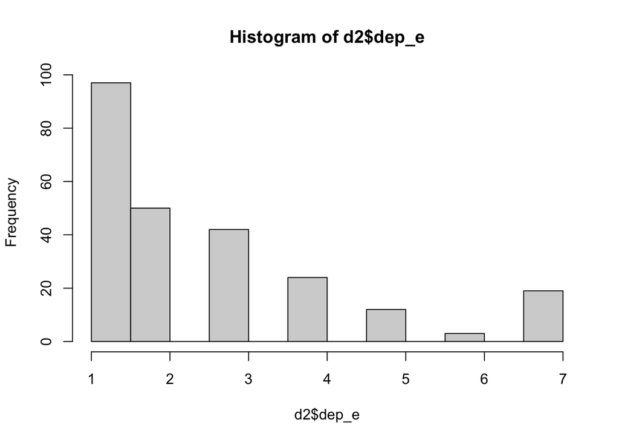

```r
d2 <- d2 %>% filter(forecast_1 < 11)
d2 <- d2 %>% filter(dep_e > 0)
hist(d2$dep_e)
```

## 2.

```r
names(d2)
```

```
##  [1] "id"         "forecast_1" "forecast_2" "forecast_3" "forecast_4"
##  [6] "dep_a"      "dep_b"      "dep_c"      "dep_d"      "dep_e"
## [11] "dep_f"
```

```r
depression <- c("dep_a", "dep_b", "dep_c", "dep_d", "dep_e", "dep_f")
d2$dep_m <- varScore(d2, Forward = c("dep_a", "dep_b", "dep_c", "dep_d", "dep_e", "dep_f"),
                     Range = c(1,7), Prorate = T, MaxMiss = 0.25) / 6
psych::alpha(d2[,depression])
```

```
##
## Reliability analysis
## Call: psych::alpha(x = d2[, depression])
##
##   raw_alpha std.alpha G6(smc) average_r S/N   ase mean  sd median_r
##       0.77      0.76    0.74      0.35 3.2 0.023  2.5 1.2     0.35
##
##     95% confidence boundaries
##          lower alpha upper
## Feldt     0.72  0.77  0.81
## Duhachek  0.72  0.77  0.81
##
##  Reliability if an item is dropped:
##       raw_alpha std.alpha G6(smc) average_r S/N alpha se  var.r med.r
## dep_a      0.75      0.75    0.72      0.38 3.1    0.025 0.0027  0.39
## dep_b      0.72      0.72    0.68      0.34 2.6    0.028 0.0037  0.34
## dep_c      0.72      0.72    0.68      0.34 2.6    0.028 0.0029  0.34
## dep_d      0.73      0.73    0.69      0.35 2.7    0.027 0.0047  0.34
## dep_e      0.72      0.72    0.68      0.34 2.5    0.028 0.0036  0.33
## dep_f      0.74      0.73    0.70      0.36 2.8    0.026 0.0055  0.37
##
##  Item statistics
##         n raw.r std.r r.cor r.drop mean  sd
## dep_a 246  0.60  0.61  0.47   0.41  2.4 1.6
## dep_b 247  0.71  0.70  0.62   0.54  2.6 1.8
## dep_c 247  0.71  0.70  0.62   0.54  2.5 1.8
## dep_d 247  0.68  0.68  0.59   0.51  2.5 1.7
## dep_e 247  0.72  0.71  0.63   0.55  2.6 1.8
## dep_f 247  0.66  0.67  0.56   0.49  2.4 1.8
##
## Non missing response frequency for each item
##          1    2    3    4    5    6    7 miss
## dep_a 0.40 0.23 0.16 0.08 0.08 0.02 0.03    0
## dep_b 0.36 0.23 0.15 0.10 0.06 0.04 0.06    0
## dep_c 0.40 0.21 0.15 0.10 0.04 0.04 0.06    0
## dep_d 0.40 0.22 0.15 0.10 0.04 0.03 0.06    0
## dep_e 0.39 0.20 0.17 0.10 0.05 0.01 0.08    0
## dep_f 0.43 0.22 0.12 0.08 0.07 0.03 0.05    0
```

```r
forecast <- c("forecast_1", "forecast_2", "forecast_3", "forecast_4")
d2$forecast_m <- varScore(d2, Forward = c("forecast_1", "forecast_2", "forecast_3", "forecast_4"), Range = c(0,10), Prorate = T, MaxMiss = 0.25) / 4
psych::alpha(d2[,forecast])
```

```
## Number of categories should be increased  in order to count frequencies.
```

```
##
## Reliability analysis
## Call: psych::alpha(x = d2[, forecast])
##
##   raw_alpha std.alpha G6(smc) average_r S/N   ase mean  sd median_r
##       0.75      0.75     0.7      0.43 3.1 0.025  4.8 1.7     0.43
##
##     95% confidence boundaries
##          lower alpha upper
## Feldt     0.70  0.75   0.8
## Duhachek  0.71  0.75   0.8
##
##  Reliability if an item is dropped:
##            raw_alpha std.alpha G6(smc) average_r S/N alpha se   var.r med.r
## forecast_1      0.71      0.71    0.62      0.45 2.4    0.032 0.00096  0.46
## forecast_2      0.71      0.71    0.62      0.45 2.5    0.032 0.00193  0.47
## forecast_3      0.70      0.70    0.62      0.44 2.4    0.032 0.00239  0.46
## forecast_4      0.67      0.67    0.57      0.40 2.0    0.037 0.00016  0.40
##
##  Item statistics
##              n raw.r std.r r.cor r.drop mean  sd
## forecast_1 247  0.75  0.75  0.61   0.53  4.7 2.3
## forecast_2 246  0.73  0.74  0.60   0.53  4.9 2.0
## forecast_3 246  0.76  0.75  0.62   0.54  4.9 2.3
## forecast_4 247  0.80  0.79  0.70   0.61  4.9 2.3
```

The alpha score for the composite depression scale is .766, which is acceptable. The alpha score for the composite forecasting scale is .755, which is also acceptable.

## 3.

```r
m4 <- lm(dep_m ~ forecast_m, data = d2)
summary(m4)
```

```
##
## Call:
## lm(formula = dep_m ~ forecast_m, data = d2)
##
## Residuals:
##     Min      1Q  Median      3Q     Max
## -2.2189 -0.7908 -0.1113  0.6811  2.8687
##
## Coefficients:
##             Estimate Std. Error t value Pr(>|t|)
## (Intercept)  4.14843    0.20308  20.427  < 2e-16 ***
## forecast_m  -0.33905    0.03961  -8.561 1.25e-15 ***
## ---
## Signif. codes:  0 '***' 0.001 '**' 0.01 '*' 0.05 '.' 0.1 ' ' 1
##
## Residual standard error: 1.049 on 245 degrees of freedom
## Multiple R-squared:  0.2302, Adjusted R-squared:  0.2271
## F-statistic: 73.28 on 1 and 245 DF,  p-value: 1.254e-15
```

```r
car::Anova(m4, type = 3) %>% eta_squared()
```

```
## For one-way between subjects designs, partial eta squared is equivalent
##   to eta squared. Returning eta squared.
```

```
## # Effect Size for ANOVA
##
## Parameter  | Eta2 |       95% CI
## --------------------------------
## forecast_m | 0.23 | [0.16, 1.00]
##
## - One-sided CIs: upper bound fixed at [1.00].
```

The effect of predicting future feelings on depression is -0.339; for every one unit increase in effective forecasting scores, depression scores are predicted to decrease by 0.339 F(1,245)=73.28, p < .001, ηp2 = .23.

## 4.

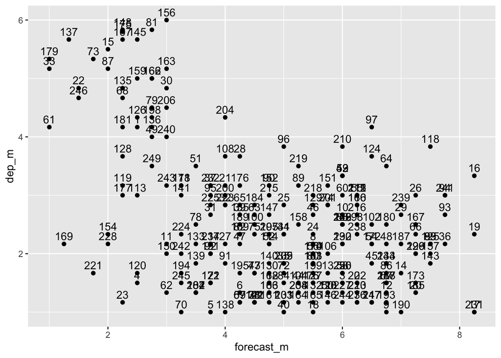

```r
ggplot(data = d2, aes(x=forecast_m, y=dep_m, label = id)) +
  geom_point() + geom_text(vjust = -.5)
```

## 5.

```r
x_hats <- modelCaseAnalysis(m4, Type = "HATVALUES") #33, 61, 176
```

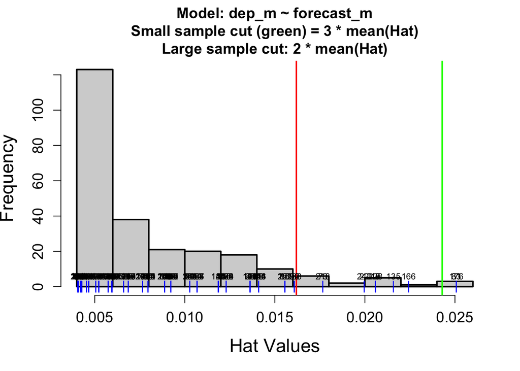

```r
x_resids <- modelCaseAnalysis(m4, Type = "RESIDUALS")
```

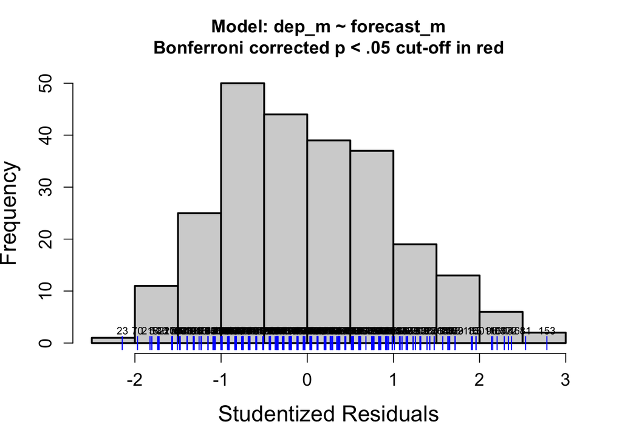

```r
x_cooks <- modelCaseAnalysis(m4, Type = "COOKSD") #16, 135, 146
```

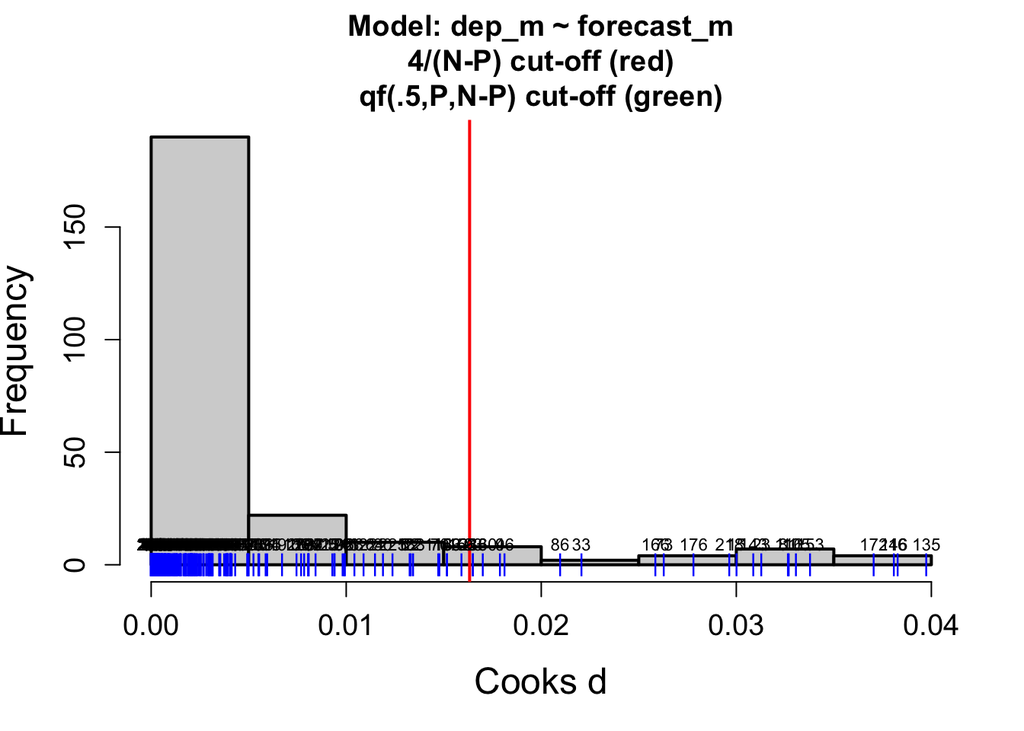

## 6

```r
modelAssumptions(m4, "NORMAL")
```

```
## Descriptive Statistics for Studentized Residuals
```

```
##    vars   n mean   sd median trimmed  mad   min  max range skew kurtosis   se
## X1    1 247    0 1.01  -0.11   -0.04 1.06 -2.14 2.78  4.93 0.36    -0.44 0.06
```

```r
modelAssumptions(m4, "CONSTANT")
```

```
##
## Suggested power transformation:  0.03291894
##
##
## Non-constant Variance Score Test
## Variance formula: ~ fitted.values
## Chisquare = 26.45654, Df = 1, p = 2.6953e-07
```

```r
modelAssumptions(m4, "LINEAR")
```

[output not shown]

The errors seem to be normally distributed. The errors for each predicted value do not have a constant spread, it is increasing. The relationship between the variables is not linear, to correct this I would transform either x or y down.

## 7.

Again, I would transform either x or y down.

## 8.

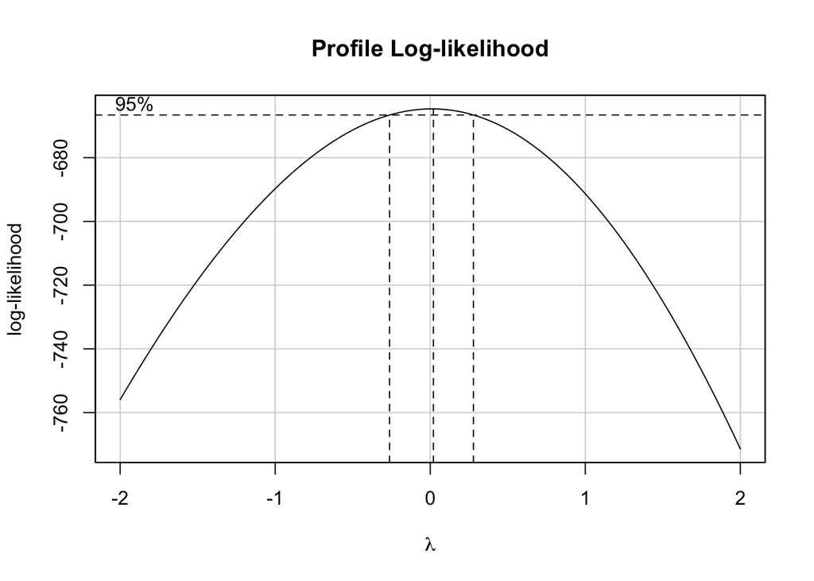

```
## [1] "Best Lambda= 0.02"
## [1] "Chi-square (df=1)= 54.41"
## [1] "p-value= 0"
```

```r
modelBoxCox(m4) # best lambda = .02
```

```r
d2$dep_m_log2 <- log2(d2$dep_m)
m5 <- lm(dep_m_log2 ~ forecast_m, data = d2)
summary(m5)
```

```
##
## Call:
## lm(formula = dep_m_log2 ~ forecast_m, data = d2)
##
## Residuals:
##     Min      1Q  Median      3Q     Max
## -1.4296 -0.4877  0.0728  0.4742  1.1913
##
## Coefficients:
##             Estimate Std. Error t value Pr(>|t|)
## (Intercept)  1.95139    0.11657  16.740  < 2e-16 ***
## forecast_m  -0.16055    0.02273  -7.062 1.69e-11 ***
## ---
## Signif. codes:  0 '***' 0.001 '**' 0.01 '*' 0.05 '.' 0.1 ' ' 1
##
## Residual standard error: 0.6024 on 245 degrees of freedom
## Multiple R-squared:  0.1691, Adjusted R-squared:  0.1657
## F-statistic: 49.87 on 1 and 245 DF,  p-value: 1.691e-11
```

## 9.

```r
d2$dep_m_log2 <- log2(d2$dep_m)
m5 <- lm(dep_m_log2 ~ forecast_m, data = d2)
summary(m5)
```

```
##
## Call:
## lm(formula = dep_m_log2 ~ forecast_m, data = d2)
##
## Residuals:
##     Min      1Q  Median      3Q     Max
## -1.4296 -0.4877  0.0728  0.4742  1.1913
##
## Coefficients:
##             Estimate Std. Error t value Pr(>|t|)
## (Intercept)  1.95139    0.11657  16.740  < 2e-16 ***
## forecast_m  -0.16055    0.02273  -7.062 1.69e-11 ***
## ---
## Signif. codes:  0 '***' 0.001 '**' 0.01 '*' 0.05 '.' 0.1 ' ' 1
##
## Residual standard error: 0.6024 on 245 degrees of freedom
## Multiple R-squared:  0.1691, Adjusted R-squared:  0.1657
## F-statistic: 49.87 on 1 and 245 DF,  p-value: 1.691e-11
```

```r
modelAssumptions(m5, Type = "LINEAR")
```

[output not shown]

It did not fix the linearity problem, but it has definitely improved.

## 10.

```r
car::Anova(m5, type=3) %>% eta_squared()
```

```
## For one-way between subjects designs, partial eta squared is equivalent
##   to eta squared. Returning eta squared.
```

```
## # Effect Size for ANOVA
##
## Parameter  | Eta2 |       95% CI
## --------------------------------
## forecast_m | 0.17 | [0.10, 1.00]
##
## - One-sided CIs: upper bound fixed at [1.00].
```

A 6.25 unit decrease in forecast leads to a doubling in depression scores. F(1,245)=49.87, p<.001, np2 = .17.

# Study 3

## 1.

```r
d3 <- read.csv("utility_value.csv") %>% janitor::clean_names()
describe(d3)
```

```
##              vars   n mean   sd median trimmed  mad  min max range  skew
## intervention    1 500 0.47 0.50   0.00    0.46 0.00 0.00   1  1.00  0.12
## stem            2 500 0.49 0.50   0.00    0.49 0.00 0.00   1  1.00  0.03
## exp             3 500 2.52 1.70   3.00    2.52 1.48 0.00   5  5.00 -0.04
## gpa             4 500 2.52 0.71   2.44    2.51 0.56 0.03   4  3.97  0.09
##              kurtosis   se
## intervention    -1.99 0.02
## stem            -2.00 0.02
## exp             -1.26 0.08
## gpa              0.21 0.03
```

```r
correlate(d3)
```

```
## Correlation computed with
## • Method: 'pearson'
## • Missing treated using: 'pairwise.complete.obs'
```

```
## # A tibble: 4 × 5
##   term         intervention     stem      exp     gpa
##   <chr>               <dbl>    <dbl>    <dbl>   <dbl>
## 1 intervention     NA       -0.0210   0.00411  0.0700
## 2 stem             -0.0210  NA       -0.00457  0.106
## 3 exp               0.00411 -0.00457 NA        0.128
## 4 gpa               0.0700   0.106    0.128   NA
```

None of the variables have impossible values. The strongest relationship is between experience and gpa (0.128). The weakest relationship is between experience and intervention (0.004). None of these relationships are unusual.

## 2.

```r
d3$stem_c <- dplyr::recode(d3$stem, "0" = -0.5, "1" = 0.5)
d3$intervention_c <- dplyr::recode(d3$intervention, "0" = -0.5, "1" = 0.5)

m6 <- lm(gpa ~ stem_c*intervention_c, data = d3)
```

## 3.

```r
summary(m6)
```

```
##
## Call:
## lm(formula = gpa ~ stem_c * intervention_c, data = d3)
##
## Residuals:
##      Min       1Q   Median       3Q      Max
## -2.46549 -0.39657 -0.07992  0.38714  1.54076
##
## Coefficients:
##                       Estimate Std. Error t value Pr(>|t|)
## (Intercept)            2.52968    0.03141  80.525   <2e-16 ***
## stem_c                 0.16020    0.06283   2.550   0.0111 *
## intervention_c         0.10463    0.06283   1.665   0.0965 .
## stem_c:intervention_c  0.24791    0.12566   1.973   0.0491 *
## ---
## Signif. codes:  0 '***' 0.001 '**' 0.01 '*' 0.05 '.' 0.1 ' ' 1
##
## Residual standard error: 0.7009 on 496 degrees of freedom
## Multiple R-squared:  0.02422,    Adjusted R-squared:  0.01831
## F-statistic: 4.103 on 3 and 496 DF,  p-value: 0.006819
```

2.53 is the predicted GPA for hypothetical participants who were halfway between interventions and stem classes. 0.16 is the effect of STEM classes on GPA when controlling for intervention and their interaction. 0.105 is the effect of intervention when controlling for STEM classes and their interaction. 0.248 is the interaction effect of STEM classes and intervention when controlling for their individual effects.

## 4.

gpa = 2.53 + 0.16stem + 0.105intervention + .248stem*intervention gpa = 2.53 + 0.16(-.5) + 0.105intervention + .248(-.5)intervention gpa = 2.53 - 0.08 + .105intervention - 0.124intervention gpa = 2.45 - 0.019intervention

-0.019 is the simple effect of intervention for participants in a non-STEM course.

## 5.

### a.

gpa = 2.53 + 0.16(-.5) + 0.105(.5) + .248(-.5)*(.5) gpa = 2.44

### b.

gpa = 2.53 + 0.16(.5) + 0.105(.5) + .248(.5)*(.5) gpa = 2.72

### c.

gpa = 2.53 + 0.16(-.5) + 0.105(-.5) + .248(-.5)*(-.5) gpa = 2.46

### d.

gpa = 2.53 + 0.16(.5) + 0.105(-.5) + .248(.5)*(-.5) gpa = 2.50

## 6.

```r
d3$exp_c <- d3$exp - mean(d3$exp)
m7 <- lm(gpa ~ stem_c*exp_c, data = d3)
```

## 7.

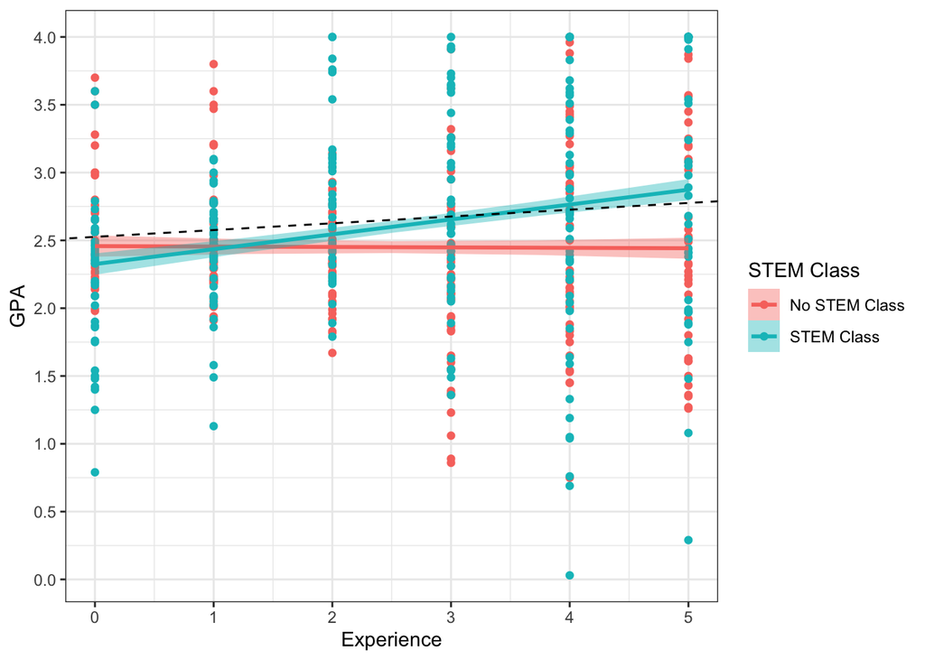

```r
d3$stem_str <- as.factor(if_else(d3$stem == 0, "No STEM Class", "STEM Class"))
m7_graph <- lm(gpa ~ stem_str*exp, data = d3)

d_graph2 <- expand.grid(exp = seq(min(d3$exp), max(d3$exp), length = 5),
                        stem_str = c('No STEM Class', 'STEM Class'))

d_graph2 <- ggplotPredict(m7_graph, d_graph2)

plot <- ggplot(d3, aes(x = exp, y = gpa, color = stem_str, fill = stem_str)) +
  geom_point() +
  geom_smooth(data = d_graph2, stat = "identity",
              aes(y = Predicted, ymin = CILo, ymax = CIHi))+
  scale_x_continuous("Experience",
                     breaks = seq(0, 5, by=1)) +
  scale_y_continuous("GPA",
                     breaks = seq(0, 4, by = .5)) +
  labs(x = "Experience", y = "GPA", main = "GPA vs Experience by STEM Classes",
       color = "STEM Class", fill = "STEM Class") +
  theme_bw()

plot <- plot +
  geom_abline(intercept = 2.526,
              slope = 0.05,
              linetype = "dashed")

plot
```

## 9.

```r
summary(m7)
```

```
##
## Call:
## lm(formula = gpa ~ stem_c * exp_c, data = d3)
##
## Residuals:
##      Min       1Q   Median       3Q      Max
## -2.73411 -0.38004 -0.04395  0.40463  1.55796
##
## Coefficients:
##              Estimate Std. Error t value Pr(>|t|)
## (Intercept)   2.52567    0.03100  81.482  < 2e-16 ***
## stem_c        0.15137    0.06199   2.442  0.01497 *
## exp_c         0.05324    0.01827   2.914  0.00373 **
## stem_c:exp_c  0.11287    0.03654   3.089  0.00212 **
## ---
## Signif. codes:  0 '***' 0.001 '**' 0.01 '*' 0.05 '.' 0.1 ' ' 1
##
## Residual standard error: 0.693 on 496 degrees of freedom
## Multiple R-squared:  0.04612,    Adjusted R-squared:  0.04035
## F-statistic: 7.994 on 3 and 496 DF,  p-value: 3.264e-05
```

```r
car::Anova(m7, type = 3) %>% eta_squared()
```

```
## Type 3 ANOVAs only give sensible and informative results when covariates
##   are mean-centered and factors are coded with orthogonal contrasts (such
##   as those produced by `contr.sum`, `contr.poly`, or `contr.helmert`, but
##   *not* by the default `contr.treatment`).
```

```
## # Effect Size for ANOVA (Type III)
##
## Parameter    | Eta2 (partial) |       95% CI
## --------------------------------------------
## stem_c       |           0.01 | [0.00, 1.00]
## exp_c        |           0.02 | [0.00, 1.00]
## stem_c:exp_c |           0.02 | [0.00, 1.00]
##
## - One-sided CIs: upper bound fixed at [1.00].
```

Our model predicts a GPA of 2.53 for participants who were hypothetically halfway between STEM class conditions and for participants who were average in experience. Taking a STEM course is predicted to increase GPA by 0.15 when controlling for experience. Having more experience (one unit higher on content experience score) is predicted to increase GPA by 0.053 when controlling for STEM courses. 0.113 is how much the effect of experience on GPA differs between STEM and non-STEM classes. F(3,496) = 7.993, p < .001, np2 = .02.